# Prosper Loan Data Exploration

## by Temitope Ayano

## Investigation Overview

> The main feature of interest is Borrower APR. I investigated features that determines the APR. The borrowers status such as Occupation, EmploymentStatus, Prosper score and their previous loan history helped to provide insight into the Borrower APR. The Key insights for presentation include:
> 1. What is the distribution of BorrowerAPR and BorrowerRate?
> 2. Which is the dominant employment status among borrowers and Term?
> 3. What is the correlations between features in the data?
> 4. Does ProsperScore affect Borrowers APR and Borrowers Rate?
> 5. What is the relationship between the Prosper Rating and other Categorical Variables?
> 6. Does Prosper Rating affect APR and Term?
> 7. Does Prosper Rating affect LoanOriginalAmount and Term?

## Dataset Overview

> The Prosper Loan Data was used. Prosper was founded in 2005 and was the first peer-to-peer lending marketplace in the United States.

> Prosper has facilitated more than 21 Dollars billion in loans to over 1.3M people. Through Prosper, people can invest in each other in a way that is financially and socially rewarding. Borrowers apply online for a fixed-rate, fixed-term loan between 2,000 and 50,000 dollars.

> Individuals and institutions can invest in the loans and earn attractive returns. Prosper handles all loan servicing on behalf of the matched borrowers and investors.

> The data set contains 113,937 loans with 81 variables on each loan, including loan amount, borrower rate (or interest rate), current loan status, borrower income, and many others.

## What is the distribution of BorrowerAPR and BorrowerRate?

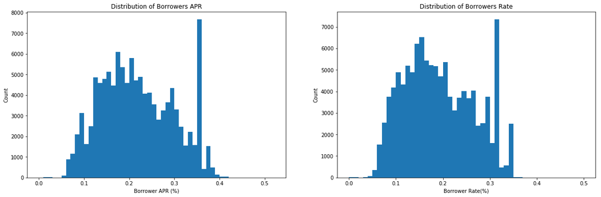

## Which is the dominant employment status among borrowers and Term?

> The most dominant employment status is 'Employed' which means that most of the borrowers (about 70,000) are employed.

> It can be deduced from the above that people who are employed tend to borrow more than those who are not.

> According to the distribution of Term, a greater number of the loan have a term of 36 months and few with 60 and 12 months term. This also reveals that ponly a small number of borrowers are granted loan that are more than 36 months Term.

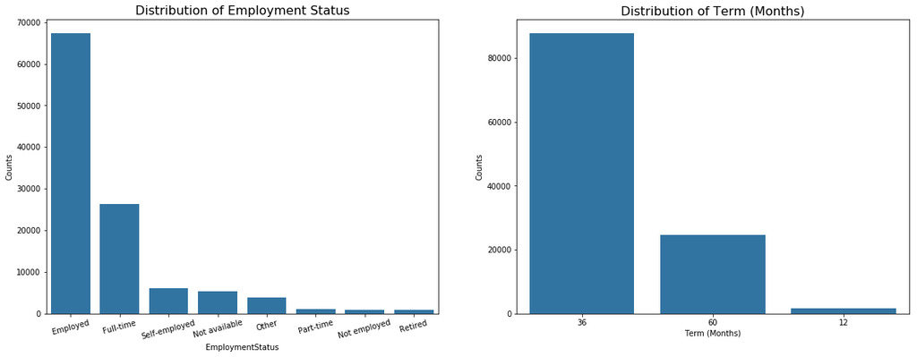

## What is the correlations between features in the data?

> Borrowers APR and Borrowers Rate are highly positively correlated with a correlation coefficient of 0.99.

> Also, the Loan Original amount and Monthly Loan payment are positively correlated. This makes sense, since individuals with high loan amount will have to pay larger amount when paying back every month.

> APR is negatively correlated with other numerical variables aside the BorrowersRate.

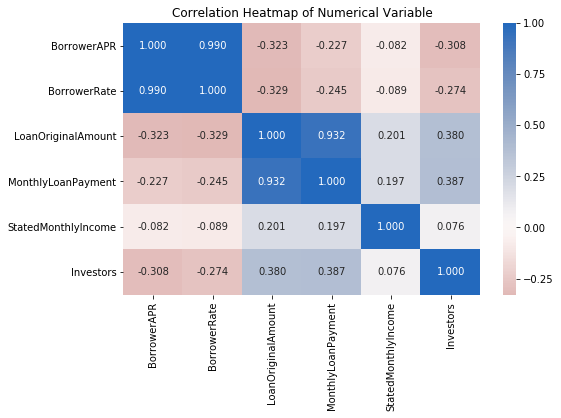

## Does ProsperScore affect Borrowers APR?

Prosper Score does affect Borrower APR. Borrower with higher prosper score have a low Borrower APR.

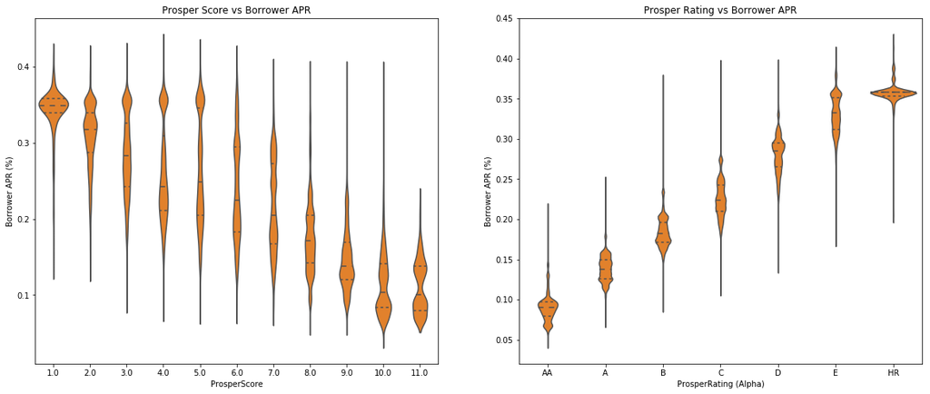

## What is the relationship between the Prosper Rating and other Categorical Variables?

- Prosper rating and term

  > Borrowers with 'A' Prosper rating have the highest count of 36month loan term. This tends to decrease with decreasing prosper rating. Borrowers with the lowest rating('HR') do not have any count for 60 months loan term. Since these borrowers are less trustworthy, they may not be granted long term loan.
- Prosper rating and employment status

  > The employed category have the highest count with most of them belonging to the 'C' rating group.
- Income and term

  > The 50k to 74,99k category have the highest count with most of them belonging to the 'C' rating group.

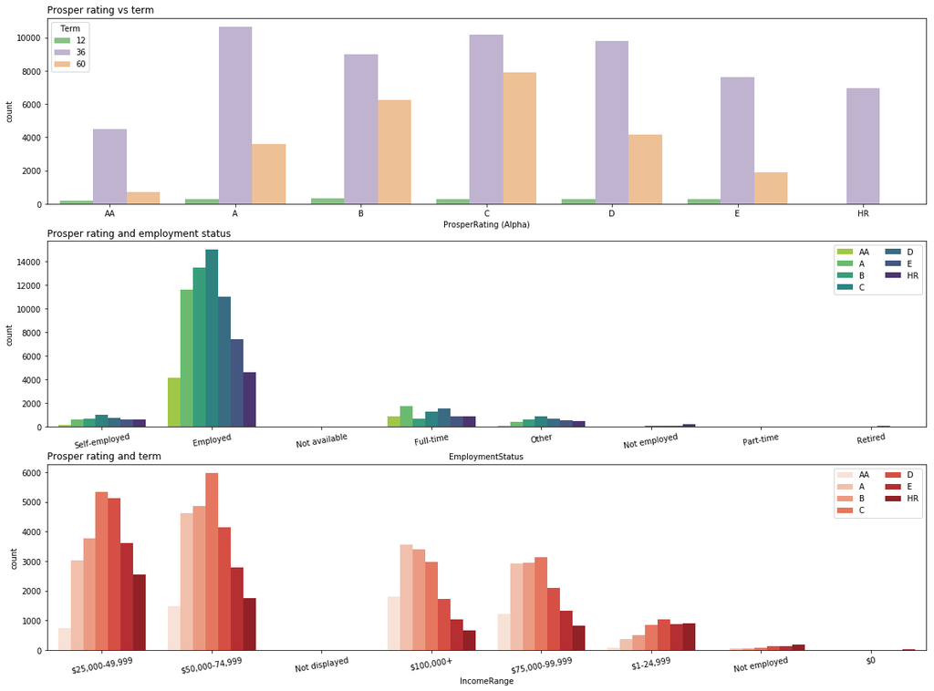

## Does Prosper Rating affect APR and Term?

> Prosper rating and Term decreases with increasing borrower APR, and Stated monthly income decreases with decreasing rating and term.

> Borrowers who earn high amount of money tends to get better rating and Borrowers with better rating tends to get long term loan repayment coupled with low APR.

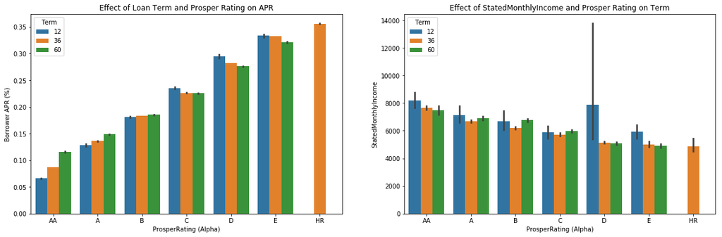

## Does Prosper Rating affect LoanOriginalAmount and Term?

> Loan Original amount decreases with decreasing Rating and borrow term.

> Borrowers who borrow large amount of money also get better rating and Loan Term.

```
Text(0,0.5,'Loan Original Amount ($)')
```

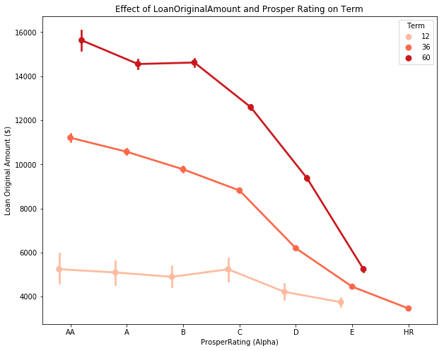